# A Graphical Model for Rating Teams

Evgeni Ovcharov

February 22, 2018

## Description of the model

Let us take $n$ teams and choose for them ratings $\theta=(\theta_1, \theta_2, \dots, \theta_n)$. By $p_{ij}$ we denote the probability that team $j$ defeats team $i$. These probabilities are modelled as follows: $p_{ij} = \frac{\theta_j}{\theta_i+\theta_j}$, for $i\not j$. Note that $p_{ji}=1-p_{ij}$. We also conisider the Bernoulli variables $Y_{ij}\sim \text{Bern}(p_{ij})$ for $1\leq i<j\leq n$. Each $Y_{ij}$ takes $1$ if team $j$ wins against team $i$ or $0$ otherwise. We first write a function which given a vector of ratings $\theta$ create the corresponding matrix $(p_{ij})$ of probabilities. We set the diagonal terms $p_{ii}$ equal to 0.

```r
p_matrix = function(theta){
  l = length(theta)
  m = matrix(0, nrow = l, ncol =l)
  for(i in 1:l){
    for(j in 1:l){
      if (i != j) m[i,j] = theta[j]/(theta[i] + theta[j])
    }
  }
  return(m)
}
```

For example, for $n=3$ and $\theta=(1,2,3)$, we have

```r
p_matrix(c(1,2,3))
```

```
##       [,1]  [,2] [,3]
## [1,] 0.000 0.667 0.75
## [2,] 0.333 0.000 0.60
## [3,] 0.250 0.400 0.00
```

The resulting matrix is not stochastic, i.e. its row vectors are not probability distributions. We turn the probability matrix into a stochastic one by giving the diagonal elements $p_{ii}$ the following values: $p_{ii} = n-1 - \sum_j p_{ij}$ and then we normalize the resulting matrix by dividing each element by $n-1$. The function which computes this matrix is given below.

```r
g_matrix = function(theta){
  l = length(theta)
  m = p_matrix(theta)
  for(i in 1: l){
    m[i,i] = l - 1 - sum(m[i,])
  }
  return(m/(l-1))
}
```

For example, for $n=3$ and $\theta=(1,2,3)$, we have

```r
graph_mat = g_matrix(c(1,2,3))
graph_mat
```

```
##       [,1]  [,2]  [,3]
## [1,] 0.292 0.333 0.375
## [2,] 0.167 0.533 0.300
## [3,] 0.125 0.200 0.675
```

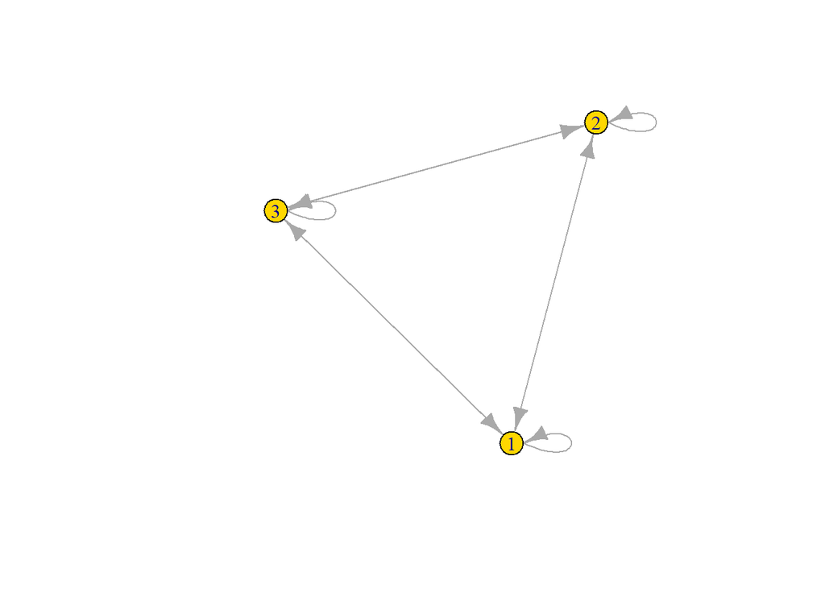

```r
g = graph_from_adjacency_matrix(graph_mat, weighted = T)
V(g)$name = 1:3
plot(g, vertex.color="gold", vertex.size=15)
```

We recall from Markov chain theory that under certain technical conditions the graph will have a stationary distribution which is proportional to the principal eigenvector of its adjacency matrix. We have constructed our graph in such a way so that its stationary distribution will be proportional to $\theta$. Let us check this on the last example.

```r
ev = eigen(t(graph_mat))
q = ev$vectors[,1]
q = Re(q/sum(q))
q
```

```
## [1] 0.167 0.333 0.500
```

So we see that the principal eigenvector $q=(1/6, 1/3, 1/2)$ is collinear to the ratings vector $\theta=(1,2,3)$.

## Comparison with the Elo rating system

We are going to use the built-in R library `PlayerRatings`, which contains an implementation of the Elo rating system. The specific method requires the data to be in the form of a dataframe containing four columns: Week, Home, Away, Score. The Week column contains information of the time period of each game. The columns Home and Away specify an identifier for the playing teams, while the column Score presents the result of the game betwen the home and away teams. Victory for the home team is encoded by 1, while victory for the away team is encoded by 0. On the other hand, our graph method requires the data to be put in the form of a graph, or more precisely, in the form of the stochastic adjacency matrix of a random graph.

We next write a function that produces the required data for both methods. The function takes an argument $n$, which specifies the number of games each team plays with any other team, and an argument $\theta$, which is the vector of true ratings. For each edge $i\rightarrow j$ in the graph, with $i < j$, we draw $n$ observations $y_1,\dots, y_n$ from Bern$(\frac{\theta_j}{\theta_i+\theta_j})$. For the Elo data, we use these outcomes to create rows in the dataframe. For our method, we compute the estimators
$$\hat p_{ij} = \frac 1 n \sum_k y_k, \qquad \hat p_{ji} = \frac{n - \sum_k y_k} n$$
of the true probabilities $p_{ij}$ and $p_{ji}$.

```r
empirical_data = function(n_trials, theta){
  n = n_trials                   #number of matches between two teams
  l = length(theta)              #number of teams
  p = p_matrix(theta)            #the true probabilities of success
  d = data.frame(Week=0, Home=0, Away=0, Score=0)
  m = matrix(0, nrow = l, ncol = l)
  store_x = numeric()

  for(i in 1:(l-1)){
    for(j in (i+1):l){
      x = rbinom(1, n, p[i,j])
      store_x = c(store_x, x)
      m[i,j] = x/n; m[j,i] = 1 - x/n
      d1 = data.frame(Week=0, Home=rep(i, n), Away=rep(j,n), Score=1)
      pos = sample(n,x)
      d1$Score[pos] = 0
      d = rbind(d, d1)
    }
  }

  for(i in 1: l){
    m[i,i] = l - 1 - sum(m[i,])
  }
  m = m/(l-1)

  d = d[-1,]
  d["Week"] = 1:n
  info = list(n_successes = store_x, n_trials = n)
  list(data = d, mat = m, info = info)
}

empirical_data(2, c(1,2,3))
```

```
## $data
##   Week Home Away Score
## 2    1    1    2     0
## 3    2    1    2     0
## 4    1    1    3     1
## 5    2    1    3     1
## 6    1    2    3     0
## 7    2    2    3     1
##
## $mat
##      [,1] [,2] [,3]
## [1,]  0.5 0.50 0.00
## [2,]  0.0 0.75 0.25
## [3,]  0.5 0.25 0.25
##
## $info
## $info$n_successes
## [1] 2 0 1
##
## $info$n_trials
## [1] 2
```

The two methods learn from the data the unknown ratings $\theta$. However, we are not going to compare the estimated ratings, but rather the implied probabilities for success $p_{ij}$. The following function converts $\theta$ in the vector of probabilities $p_{ij}, i<j$.

```r
probabilities = function(theta){
  l = length(theta)
  p = numeric()
  for(i in 1:(l-1)){
    for(j in (i+1):l){
      p = c(p, theta[j]/(theta[i] + theta[j]))
    }
  }
  p
}
```

The next function allows us to compare the two methods.

```r
compare_methods = function(n_trials, theta){
  a = empirical_data(n_trials, theta)

  ev = eigen(t(a$mat))
  q = ev$vectors[,1] #q = Re(q/sum(q))
  p.graph = probabilities(Re(q))

  rank = elo(a$data)
  elo_rating = rank$ratings$Rating[order(rank$ratings$Player)]
  rating = 10^(elo_rating/400) #rating = rating/sum(rating)
  p.elo = probabilities(rating)

  list(p_graph = p.graph, p_elo = p.elo)
}
```

Let us consider a short example. We take $n=5$ teams with skills $\theta=(1,2,3,4,5)$. The number of unique probabilities we need to predict is $n(n-1)/2=10$. The number of matches between any two of them is set to $n_{trials} = 25$.

```r
set.seed(100)
comp = compare_methods(25, 1:5)
comp
```

```
## $p_graph
##  [1] 0.669 0.680 0.740 0.784 0.512 0.584 0.642 0.572 0.631 0.561
##
## $p_elo
##  [1] 0.653 0.671 0.761 0.861 0.521 0.629 0.767 0.609 0.752 0.660
```

The true probabilities are

```r
prob = probabilities(1:5)
prob
```

```
##  [1] 0.667 0.750 0.800 0.833 0.600 0.667 0.714 0.571 0.625 0.556
```

The standard errors of the two methods for the above example are

```r
sqrt(sum((comp$p_graph - prob)^2)/length(prob))
```

```
## [1] 0.0553
```

```r
sqrt(sum((comp$p_elo - prob)^2)/length(prob))
```

```
## [1] 0.069
```

Let us make another, more heuristic comparison. First, let us note that each pair of teams plays $n_{trials}=25$ teams and that there are $10\cdot25=250$ games in total. Although there are 10 different pairings of teams and 10 corresponding probabilities $p_{ij}$ of success to be predicted, the model has only five degrees of freedom. This follows from the fact that all $p_{ij}$’s are functions of the five $\theta$’s. Hence, each unknown parameter $\theta_i$ is in fact estimated with 250/5 = 50 observations. Therefore, it makes sense to compare the present situation to a case where a random variable $Y\sim \text{Binom}(n,p)$ is given with $n=50$. We set $p=0.75$. The best estimator for $p$ is the maximum likelihood estimator $Y/n$. Its standard error is given by

```r
p = 0.75
n = 50
sqrt(p*(1-p)/n)
```

```
## [1] 0.0612
```

We see that our method fares favourably also with regard to the maximum likelihood estimator $\hat p = Y/n$ in a heuristic comparison.

## Comparison of errors

Here, we are going to investigate the accuracy of the two methods on one extreme case – the case where each pair of teams plays exactly one game. In other words, we have exactly one observation for the Bernoulli variables $Y_{ij} \sim \text{Bern}(p_{ij})$ to determine the unknown probabilities $p_{ij}$ for success. In the case of $n=11$ players, we randomly generate one such adjacency matrix.

```r
empirical_data(1, 1:11)$mat
```

```
##       [,1] [,2] [,3] [,4] [,5] [,6] [,7] [,8] [,9] [,10] [,11]
##  [1,]  0.3  0.0  0.0  0.1  0.1  0.1  0.0  0.1  0.1   0.1   0.1
##  [2,]  0.1  0.3  0.1  0.1  0.0  0.0  0.1  0.0  0.1   0.1   0.1
##  [3,]  0.1  0.0  0.4  0.1  0.0  0.0  0.1  0.0  0.1   0.1   0.1
##  [4,]  0.0  0.0  0.0  0.6  0.1  0.0  0.0  0.0  0.1   0.1   0.1
##  [5,]  0.0  0.1  0.1  0.0  0.3  0.1  0.1  0.1  0.1   0.0   0.1
##  [6,]  0.0  0.1  0.1  0.1  0.0  0.5  0.1  0.0  0.0   0.0   0.1
##  [7,]  0.1  0.0  0.0  0.1  0.0  0.0  0.7  0.0  0.0   0.1   0.0
##  [8,]  0.0  0.1  0.1  0.1  0.0  0.1  0.1  0.3  0.1   0.1   0.0
##  [9,]  0.0  0.0  0.0  0.0  0.0  0.1  0.1  0.0  0.7   0.1   0.0
## [10,]  0.0  0.0  0.0  0.0  0.1  0.1  0.0  0.0  0.0   0.8   0.0
## [11,]  0.0  0.0  0.0  0.0  0.0  0.0  0.1  0.1  0.1   0.1   0.6
```

The following function generates random observations for our model and measures the standard errors of the two methods.

```r
compare_methods_err = function(n, theta){
  a = empirical_data(n, theta)
  p = probabilities(theta)
  l = length(p)

  ev = eigen(t(a$mat))
  q = ev$vectors[,1]
  p.graph = probabilities(Re(q))
  err1 = sum((p.graph - p)^2)/l

  rank = elo(a$data)
  elo_rating = rank$ratings$Rating[order(rank$ratings$Player)]
  rating = 10^(elo_rating/400)
  p.elo = probabilities(rating)
  err2 = sum((p.elo - p)^2)/l

  list(err_graph = sqrt(err1), err_elo = sqrt(err2))
}
```

In the following code we compare the accuracy of the two methods for various numbers of teams in a competition where each pair of team meets exactly once. Since the computation is not very fast, we save the results in a csv file in order to reuse them.

```r
n_rep = 25; n1 = 20; n2 = 100; step = 5;
mat = matrix(nrow = 2)
for (i in seq(n1, n2, step)){
  theta = 1:i
  r = replicate(n_rep, compare_methods_err(1, theta))
  r1 = r[1,]
  r1 = unlist(r1)
  r2 = r[2,]
  r2 = unlist(r2)

  col = c(mean(r1), mean(r2))
  mat = cbind(mat, col)
}
mat = mat[,2:dim(mat)[2]]
colnames(mat) = seq(n1, n2, step)
mat
write.csv(mat, "compare.csv")
```

```r
read.csv("compare.csv", check.names=FALSE)
```

```
##      20    25    30   35    40    45    50    55    60    65    70    75    80    85    90    95   100
## 1 0.148 0.136 0.129 0.12 0.110 0.105 0.094 0.095 0.089 0.084 0.080 0.079 0.077 0.072 0.071 0.072 0.067
## 2 0.082 0.107 0.130 0.15 0.167 0.181 0.193 0.204 0.213 0.221 0.228 0.234 0.240 0.245 0.249 0.253 0.257
```